# Project: Investigate European Soccer Database

# By Jack Kwok

- Introduction
- Data Wrangling
- Exploratory Data Analysis
- Conclusions

## Introduction

### In this report, i am going to investigate european soccer database. Since the World Cup 2018 ended a month and a half ago, i got some questions on my mind. I think it is challeging and good opportunity of me to deal with such huge amount of data.

### 1. Is match getting more boring now(in terms of the goals per match)?

### 2. Is there any home team adventage?

### 3. Which factors contribute to the overall-rating of a player?

```python
#import useful libraries

import numpy as np
import pandas as pd
import matplotlib.pyplot as plt
%matplotlib inline
import sqlite3
import seaborn as sns
```

## Data Wrangling

### General Properties

```python
# Load all the tables from 'database.sqlite'
with sqlite3.connect("database.sqlite") as con:
    countries = pd.read_sql_query("SELECT * from Country", con)
    matches = pd.read_sql_query("SELECT * from Match", con)
    leagues = pd.read_sql_query("SELECT * from League", con)
    teams = pd.read_sql_query("SELECT * from Team", con)
    player = pd.read_sql_query("SELECT * from Player",con)
    player_attributes = pd.read_sql_query("SELECT * from Player_Attributes",con)
    sequence = pd.read_sql_query("SELECT * from sqlite_sequence",con)
    team_attributes = pd.read_sql_query("SELECT * from Team_Attributes",con)
```

```python
# Take a look at each table
countries.head()
leagues.head()
matches.head()
teams.head()
player.head()
player_attributes.head()
sequence.head()
team_attributes.head()
```

|  | id | team_fifa_api_id | team_api_id | date | buildUpPlaySpeed | buildUpPlaySpeedClass | buildUpPlayDribbling | buildUpPlayDribblingClass | buildUpPlayPassing | buildUpPlayPassingClass | ... | chanceCreationShooting | chanceCreationShootingClass | chanceCreationPositioningClass | defencePressure | defencePressureClass | defenceAggression | defenceAggressionClass | defenceTeamWidth | defenceTeamWidthClass | defenceDefenderLineClass |
| --- | --- | --- | --- | --- | --- | --- | --- | --- | --- | --- | --- | --- | --- | --- | --- | --- | --- | --- | --- | --- | --- |
| 0 | 1 | 434 | 9930 | 2010-02-22 00:00:00 | 60 | Balanced | NaN | Little | 50 | Mixed | ... | 55 | Normal | Organised | 50 | Medium | 55 | Press | 45 | Normal | Cover |
| 1 | 2 | 434 | 9930 | 2014-09-19 00:00:00 | 52 | Balanced | 48.0 | Normal | 56 | Mixed | ... | 64 | Normal | Organised | 47 | Medium | 44 | Press | 54 | Normal | Cover |
| 2 | 3 | 434 | 9930 | 2015-09-10 00:00:00 | 47 | Balanced | 41.0 | Normal | 54 | Mixed | ... | 64 | Normal | Organised | 47 | Medium | 44 | Press | 54 | Normal | Cover |
| 3 | 4 | 77 | 8485 | 2010-02-22 00:00:00 | 70 | Fast | NaN | Little | 70 | Long | ... | 70 | Lots | Organised | 60 | Medium | 70 | Double | 70 | Wide | Cover |
| 4 | 5 | 77 | 8485 | 2011-02-22 00:00:00 | 47 | Balanced | NaN | Little | 52 | Mixed | ... | 52 | Normal | Organised | 47 | Medium | 47 | Press | 52 | Normal | Cover |

5 rows × 25 columns

### General properties of the matches

```python
matches.info()
```

```
<class 'pandas.core.frame.DataFrame'>
RangeIndex: 25979 entries, 0 to 25978
Columns: 115 entries, id to BSA
dtypes: float64(96), int64(9), object(10)
memory usage: 22.8+ MB
```

```python
#check null cells in the datafream
matches.isnull().any()
```

```
id                  False
country_id          False
league_id           False
season              False
stage               False
date                False
match_api_id        False
home_team_api_id    False
away_team_api_id    False
home_team_goal      False
away_team_goal      False
home_player_X1       True
home_player_X2       True
home_player_X3       True
home_player_X4       True
home_player_X5       True
home_player_X6       True
home_player_X7       True
home_player_X8       True
home_player_X9       True
home_player_X10      True
home_player_X11      True
away_player_X1       True
away_player_X2       True
away_player_X3       True
away_player_X4       True
away_player_X5       True
away_player_X6       True
away_player_X7       True
away_player_X8       True
                    ...
B365H                True
B365D                True
B365A                True
BWH                  True
BWD                  True
BWA                  True
IWH                  True
IWD                  True
IWA                  True
LBH                  True
LBD                  True
LBA                  True
PSH                  True
PSD                  True
PSA                  True
WHH                  True
WHD                  True
WHA                  True
SJH                  True
SJD                  True
SJA                  True
VCH                  True
VCD                  True
VCA                  True
GBH                  True
GBD                  True
GBA                  True
BSH                  True
BSD                  True
BSA                  True
Length: 115, dtype: bool
```

```python
# check duplicated cells in matches
matches.match_api_id.duplicated().any()
```

```
False
```

### General properties of leagues table

```python
#Get the information from the leagues table
leagues.info()
```

```
<class 'pandas.core.frame.DataFrame'>
RangeIndex: 11 entries, 0 to 10
Data columns (total 3 columns):
id            11 non-null int64
country_id    11 non-null int64
name          11 non-null object
dtypes: int64(2), object(1)
memory usage: 344.0+ bytes
```

```python
#check null cells in the datafream
leagues.isnull().any()
```

```
id            False
country_id    False
name          False
dtype: bool
```

```python
# check duplcated cells in leagues
leagues.id.duplicated().any()
```

```
False
```

### General properties of player_attributes table

```python
player_attributes.info()
```

```
<class 'pandas.core.frame.DataFrame'>
RangeIndex: 183978 entries, 0 to 183977
Data columns (total 42 columns):
id                     183978 non-null int64
player_fifa_api_id     183978 non-null int64
player_api_id          183978 non-null int64
date                   183978 non-null object
overall_rating         183142 non-null float64
potential              183142 non-null float64
preferred_foot         183142 non-null object
attacking_work_rate    180748 non-null object
defensive_work_rate    183142 non-null object
crossing               183142 non-null float64
finishing              183142 non-null float64
heading_accuracy       183142 non-null float64
short_passing          183142 non-null float64
volleys                181265 non-null float64
dribbling              183142 non-null float64
curve                  181265 non-null float64
free_kick_accuracy     183142 non-null float64
long_passing           183142 non-null float64
ball_control           183142 non-null float64
acceleration           183142 non-null float64
sprint_speed           183142 non-null float64
agility                181265 non-null float64
reactions              183142 non-null float64
balance                181265 non-null float64
shot_power             183142 non-null float64
jumping                181265 non-null float64
stamina                183142 non-null float64
strength               183142 non-null float64
long_shots             183142 non-null float64
aggression             183142 non-null float64
interceptions          183142 non-null float64
positioning            183142 non-null float64
vision                 181265 non-null float64
penalties              183142 non-null float64
marking                183142 non-null float64
standing_tackle        183142 non-null float64
sliding_tackle         181265 non-null float64
gk_diving              183142 non-null float64
gk_handling            183142 non-null float64
gk_kicking             183142 non-null float64
gk_positioning         183142 non-null float64
gk_reflexes            183142 non-null float64
dtypes: float64(35), int64(3), object(4)
memory usage: 59.0+ MB
```

```python
player_attributes.isnull().sum()
```

```
id                        0
player_fifa_api_id        0
player_api_id             0
date                      0
overall_rating          836
potential               836
preferred_foot          836
attacking_work_rate    3230
defensive_work_rate     836
crossing                836
finishing               836
heading_accuracy        836
short_passing           836
volleys                2713
dribbling               836
curve                  2713
free_kick_accuracy      836
long_passing            836
ball_control            836
acceleration            836
sprint_speed            836
agility                2713
reactions               836
balance                2713
shot_power              836
jumping                2713
stamina                 836
strength                836
long_shots              836
aggression              836
interceptions           836
positioning             836
vision                 2713
penalties               836
marking                 836
standing_tackle         836
sliding_tackle         2713
gk_diving               836
gk_handling             836
gk_kicking              836
gk_positioning          836
gk_reflexes             836
dtype: int64
```

```python
#Since there are very small porpotion of Null cell, then we can drop it
player_attributes.dropna(axis = 0,inplace=True )
```

```python
# check the null cells again
player_attributes.isnull().any()
```

```
id                     False
player_fifa_api_id     False
player_api_id          False
date                   False
overall_rating         False
potential              False
preferred_foot         False
attacking_work_rate    False
defensive_work_rate    False
crossing               False
finishing              False
heading_accuracy       False
short_passing          False
volleys                False
dribbling              False
curve                  False
free_kick_accuracy     False
long_passing           False
ball_control           False
acceleration           False
sprint_speed           False
agility                False
reactions              False
balance                False
shot_power             False
jumping                False
stamina                False
strength               False
long_shots             False
aggression             False
interceptions          False
positioning            False
vision                 False
penalties              False
marking                False
standing_tackle        False
sliding_tackle         False
gk_diving              False
gk_handling            False
gk_kicking             False
gk_positioning         False
gk_reflexes            False
dtype: bool
```

```python
# check deuplicated cells in player_attributes
player_attributes.id.duplicated().any()
```

```
False
```

### Load neccessary columns in each tables

```python
#In order to answer Q1 and Q2, we only need to consider serveral columns of matches
matches.head()
matches = matches[['country_id','league_id', 'season', 'home_team_goal', 'away_team_goal']]
matches
```

|  | country_id | league_id | season | home_team_goal | away_team_goal |
| --- | --- | --- | --- | --- | --- |
| 0 | 1 | 1 | 2008/2009 | 1 | 1 |
| 1 | 1 | 1 | 2008/2009 | 0 | 0 |
| 2 | 1 | 1 | 2008/2009 | 0 | 3 |
| 3 | 1 | 1 | 2008/2009 | 5 | 0 |
| 4 | 1 | 1 | 2008/2009 | 1 | 3 |
| 5 | 1 | 1 | 2008/2009 | 1 | 1 |
| 6 | 1 | 1 | 2008/2009 | 2 | 2 |
| 7 | 1 | 1 | 2008/2009 | 1 | 2 |
| 8 | 1 | 1 | 2008/2009 | 1 | 0 |
| 9 | 1 | 1 | 2008/2009 | 4 | 1 |
| 10 | 1 | 1 | 2008/2009 | 1 | 2 |
| 11 | 1 | 1 | 2008/2009 | 0 | 2 |
| 12 | 1 | 1 | 2008/2009 | 0 | 0 |
| 13 | 1 | 1 | 2008/2009 | 2 | 2 |
| 14 | 1 | 1 | 2008/2009 | 1 | 2 |
| 15 | 1 | 1 | 2008/2009 | 0 | 1 |
| 16 | 1 | 1 | 2008/2009 | 1 | 3 |
| 17 | 1 | 1 | 2008/2009 | 1 | 3 |
| 18 | 1 | 1 | 2008/2009 | 2 | 3 |
| 19 | 1 | 1 | 2008/2009 | 0 | 0 |
| 20 | 1 | 1 | 2008/2009 | 2 | 2 |
| 21 | 1 | 1 | 2008/2009 | 2 | 0 |
| 22 | 1 | 1 | 2008/2009 | 1 | 1 |
| 23 | 1 | 1 | 2008/2009 | 1 | 2 |
| 24 | 1 | 1 | 2008/2009 | 0 | 0 |
| 25 | 1 | 1 | 2008/2009 | 1 | 0 |
| 26 | 1 | 1 | 2008/2009 | 1 | 3 |
| 27 | 1 | 1 | 2008/2009 | 1 | 1 |
| 28 | 1 | 1 | 2008/2009 | 1 | 1 |
| 29 | 1 | 1 | 2008/2009 | 2 | 2 |
| ... | ... | ... | ... | ... | ... |
| 25949 | 24558 | 24558 | 2015/2016 | 6 | 1 |
| 25950 | 24558 | 24558 | 2015/2016 | 1 | 3 |
| 25951 | 24558 | 24558 | 2015/2016 | 0 | 2 |
| 25952 | 24558 | 24558 | 2015/2016 | 1 | 1 |
| 25953 | 24558 | 24558 | 2015/2016 | 3 | 1 |
| 25954 | 24558 | 24558 | 2015/2016 | 3 | 1 |
| 25955 | 24558 | 24558 | 2015/2016 | 0 | 1 |
| 25956 | 24558 | 24558 | 2015/2016 | 0 | 1 |
| 25957 | 24558 | 24558 | 2015/2016 | 3 | 1 |
| 25958 | 24558 | 24558 | 2015/2016 | 3 | 3 |
| 25959 | 24558 | 24558 | 2015/2016 | 1 | 3 |
| 25960 | 24558 | 24558 | 2015/2016 | 1 | 3 |
| 25961 | 24558 | 24558 | 2015/2016 | 0 | 2 |
| 25962 | 24558 | 24558 | 2015/2016 | 1 | 0 |
| 25963 | 24558 | 24558 | 2015/2016 | 2 | 5 |
| 25964 | 24558 | 24558 | 2015/2016 | 0 | 1 |
| 25965 | 24558 | 24558 | 2015/2016 | 1 | 0 |
| 25966 | 24558 | 24558 | 2015/2016 | 0 | 2 |
| 25967 | 24558 | 24558 | 2015/2016 | 3 | 1 |
| 25968 | 24558 | 24558 | 2015/2016 | 3 | 2 |
| 25969 | 24558 | 24558 | 2015/2016 | 2 | 1 |
| 25970 | 24558 | 24558 | 2015/2016 | 4 | 0 |
| 25971 | 24558 | 24558 | 2015/2016 | 3 | 3 |
| 25972 | 24558 | 24558 | 2015/2016 | 3 | 3 |
| 25973 | 24558 | 24558 | 2015/2016 | 3 | 0 |
| 25974 | 24558 | 24558 | 2015/2016 | 1 | 0 |
| 25975 | 24558 | 24558 | 2015/2016 | 1 | 2 |
| 25976 | 24558 | 24558 | 2015/2016 | 2 | 0 |
| 25977 | 24558 | 24558 | 2015/2016 | 0 | 0 |
| 25978 | 24558 | 24558 | 2015/2016 | 4 | 3 |

25979 rows × 5 columns

```python
# Merge with league to get league name into the dataframe.
df = pd.merge(leagues,matches, on = 'country_id' )
df = pd.merge(countries, df, on ='id')
```

```python
# Let's check the datafram

df.head()
```

|  | id | name_x | country_id | name_y | league_id | season | home_team_goal | away_team_goal |
| --- | --- | --- | --- | --- | --- | --- | --- | --- |
| 0 | 1 | Belgium | 1 | Belgium Jupiler League | 1 | 2008/2009 | 1 | 1 |
| 1 | 1 | Belgium | 1 | Belgium Jupiler League | 1 | 2008/2009 | 0 | 0 |
| 2 | 1 | Belgium | 1 | Belgium Jupiler League | 1 | 2008/2009 | 0 | 3 |
| 3 | 1 | Belgium | 1 | Belgium Jupiler League | 1 | 2008/2009 | 5 | 0 |
| 4 | 1 | Belgium | 1 | Belgium Jupiler League | 1 | 2008/2009 | 1 | 3 |

```python
# rename columns
df.rename(index=str, columns={"name_x": "country_name", "name_y": "league"}, inplace=True)
```

### Clearning the data

```python
# Since we don't need the country_id, id and league id, we can remove them
df.drop(['id', 'country_id' ,'league_id','league'], axis = 1, inplace = True)
```

```python
# make sure there is no null cell in the dataframe
df.isnull().any()
```

```
country_name      False
season            False
home_team_goal    False
away_team_goal    False
dtype: bool
```

```python
# rename the name column
df = df.rename(index=str, columns={"name": "league"})
```

```python
# check the unique value in dataframe
df.nunique()
```

```
country_name      11
season             8
home_team_goal    11
away_team_goal    10
dtype: int64
```

```python
df.country_name.unique()
```

```
array(['Belgium', 'England', 'France', 'Germany', 'Italy', 'Netherlands',
       'Poland', 'Portugal', 'Scotland', 'Spain', 'Switzerland'],
      dtype=object)
```

```python
df.season.unique()
```

```
array(['2008/2009', '2009/2010', '2010/2011', '2011/2012', '2012/2013',
       '2013/2014', '2014/2015', '2015/2016'], dtype=object)
```

## Exploratory Data Analysis

### Research Question 1. Finding the goals trend. is the match getting less and less goals?

```python
# For Q1, we need to find out the goals for each match
# Let's check the data type of home_team_goal and away_team_goal
df.info()
```

```
<class 'pandas.core.frame.DataFrame'>
Index: 25979 entries, 0 to 25978
Data columns (total 4 columns):
country_name      25979 non-null object
season            25979 non-null object
home_team_goal    25979 non-null int64
away_team_goal    25979 non-null int64
dtypes: int64(2), object(2)
memory usage: 1014.8+ KB
```

```python
# Then we can add these columns to get goals column
df['goals'] = df['home_team_goal'] + df['away_team_goal']
```

```python
# check the goals column
df.head()
```

|  | country_name | season | home_team_goal | away_team_goal | goals |
| --- | --- | --- | --- | --- | --- |
| 0 | Belgium | 2008/2009 | 1 | 1 | 2 |
| 1 | Belgium | 2008/2009 | 0 | 0 | 0 |
| 2 | Belgium | 2008/2009 | 0 | 3 | 3 |
| 3 | Belgium | 2008/2009 | 5 | 0 | 5 |
| 4 | Belgium | 2008/2009 | 1 | 3 | 4 |

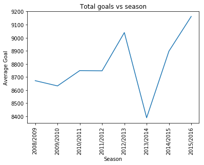

```python
#Plot the total goals vs season
m = df.groupby("season")['goals'].sum()
plt.xlabel('Season')
plt.ylabel('Average Goal')
plt.xticks(rotation=90)
plt.title('Total goals vs season')
plt.plot(m)
plt.figure(figsize=(10,10))
```

##### It seems that the total goals for each season is quite different. Let's look at the average goals per match.

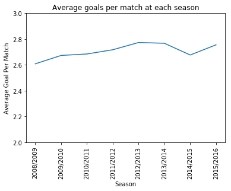

```python
#Plot the avg. goals per match vs season
m = df.groupby("season")['goals'].mean()
plt.xlabel('Season')
plt.ylabel('Average Goal Per Match')
plt.xticks(rotation=90)
plt.ylim(2,3)
plt.title('Average goals per match at each season')
plt.plot(m)
plt.figure(figsize=(10,10))
```

```python
g_diff = (m.max()-m.min())*100/m.min()
print('The percetage difference of average goals per match {}%.'.format(g_diff))
```

```
The percetage difference of average goals per match 6.342229699137494%.
```

##### As you can see, there is a trend of the goals per match increasing but it is not significant. The difference of between Max and Min less than 7%.

```python
#Let's see the trend by different countries
#Get the average goals per match of countries
s_df = df.query('country_name =="Spain"')
s_avg = s_df.groupby('season')['goals'].mean()

g_df = df.query('country_name =="Germany"')
g_avg = g_df.groupby('season')['goals'].mean()

f_df = df.query('country_name =="France"')
f_avg = f_df.groupby('season')['goals'].mean()

i_df = df.query('country_name =="Italy"')
i_avg = i_df.groupby('season')['goals'].mean()

e_df = df.query('country_name =="England"')
e_avg = e_df.groupby('season')['goals'].mean()
```

```
 <a list of 8 Text xticklabel objects>)
```

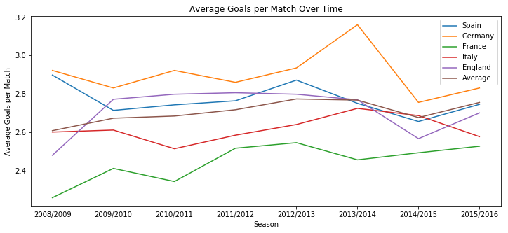

```python
#Reconstruct the dataframe and plot the average goals per match over time
sort_df = pd.DataFrame(index=np.sort(df['season'].unique()),columns = ['Spain', 'Germany', 'France', 'Italy','England','Average'])
sort_df.loc[:,'Spain']   = list(s_avg)
sort_df.loc[:,'Germany']   = list(g_avg)
sort_df.loc[:,'France']  = list(f_avg)
sort_df.loc[:,'Italy']   = list(i_avg)
sort_df.loc[:,'England']   = list(e_avg)
sort_df.loc[:,'Average'] = list(m)
sort_df
sort_df.plot(figsize=(12,5),title='Average Goals per Match Over Time')
plt.ylabel('Average Goals per Match')
plt.xlabel('Season')
seasons = df.season.unique()
plt.xticks(range(len(seasons)),seasons)
```

### Research Question 2. is there any home team adventage?

```python
def tag(df):
    if df.home_team_goal > df.away_team_goal :
        return "Home win"
    elif df.home_team_goal < df.away_team_goal :
        return "Away win"
    elif df.home_team_goal == df.away_team_goal :
        return "Draw"
```

```python
df["match_result"] = df.apply(lambda df:tag(df), axis= 1)
```

```python
# Check the match_result column
df.head()
```

|  | country_name | season | home_team_goal | away_team_goal | goals | match_result |
| --- | --- | --- | --- | --- | --- | --- |
| 0 | Belgium | 2008/2009 | 1 | 1 | 2 | Draw |
| 1 | Belgium | 2008/2009 | 0 | 0 | 0 | Draw |
| 2 | Belgium | 2008/2009 | 0 | 3 | 3 | Away win |
| 3 | Belgium | 2008/2009 | 5 | 0 | 5 | Home win |
| 4 | Belgium | 2008/2009 | 1 | 3 | 4 | Away win |

```python
df.match_result.value_counts()
```

```
Home win    11917
Away win     7466
Draw         6596
Name: match_result, dtype: int64
```

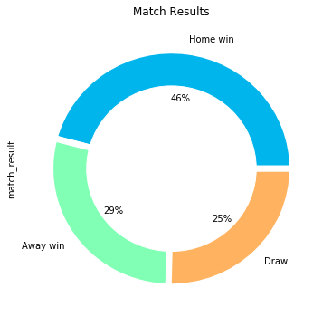

```python
#Try to show it in pie plot
plt.figure(figsize=(6,6))
df["match_result"].value_counts().plot.pie(autopct = "%1.0f%%",colors =sns.color_palette("rainbow",3),wedgeprops = {"linewidth":7,"edgecolor":"white"})
my_circ = plt.Circle((0,0),.7,color = "white")
plt.gca().add_artist(my_circ)
plt.title("Match Results")
plt.show()
```

```python
#Try to show it in bar plot
```

```python
Home_win_ratio = len(df.query('match_result == "Home win"'))/df.shape[0]
Away_win_ratio = len(df.query('match_result == "Away win"'))/df.shape[0]
Draw_ratio = len(df.query('match_result == "Draw"'))/df.shape[0]
```

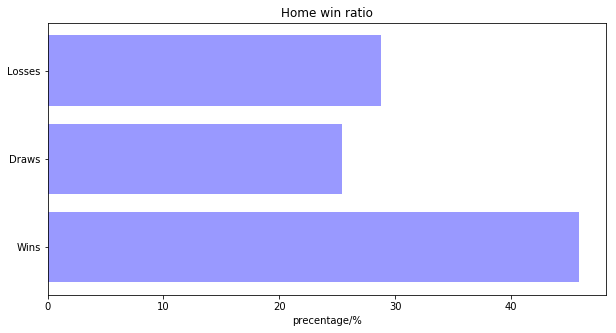

```python
plt.figure(figsize=(10,5))
labels = ['Wins', 'Draws', 'Losses']
ratio = [Home_win_ratio*100, Draw_ratio*100, Away_win_ratio*100]
y_pos = np.arange(len(ratio))
plt.barh(y_pos, ratio, align='center', alpha=0.4, color='b')
plt.yticks(y_pos, labels)
plt.xlabel('precentage/%')
plt.title('Home win ratio')
plt.show()
```

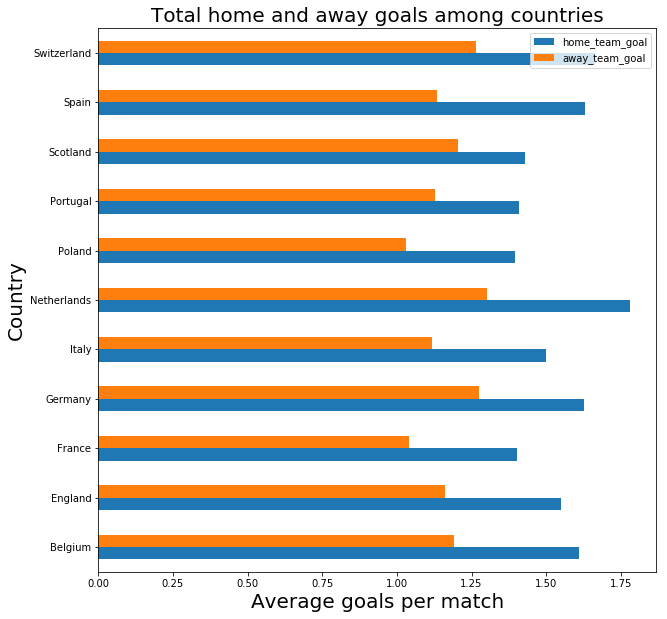

```python
#Try to get the total home and away goals among countries
df.groupby("country_name").agg({"home_team_goal":"mean","away_team_goal":"mean"}).plot(kind="barh",figsize = (10,10))
plt.ylabel('Country', size = 20)
plt.xlabel('Average goals per match', size=20)
plt.title("Total home and away goals among countries", size =20)
plt.show()
```

#### Even we look at the matches by countries, there is significant difference on goals between home and away team. So, yes. There is home advantage.

### 3. Which factors contribute to the overall-rating of a player

```python
#check the player_attributes data
player_attributes.head()
```

|  | id | player_fifa_api_id | player_api_id | date | overall_rating | potential | preferred_foot | attacking_work_rate | defensive_work_rate | crossing | ... | vision | penalties | marking | standing_tackle | sliding_tackle | gk_diving | gk_handling | gk_kicking | gk_positioning | gk_reflexes |
| --- | --- | --- | --- | --- | --- | --- | --- | --- | --- | --- | --- | --- | --- | --- | --- | --- | --- | --- | --- | --- | --- |
| 0 | 1 | 218353 | 505942 | 2016-02-18 00:00:00 | 67.0 | 71.0 | right | medium | medium | 49.0 | ... | 54.0 | 48.0 | 65.0 | 69.0 | 69.0 | 6.0 | 11.0 | 10.0 | 8.0 | 8.0 |
| 1 | 2 | 218353 | 505942 | 2015-11-19 00:00:00 | 67.0 | 71.0 | right | medium | medium | 49.0 | ... | 54.0 | 48.0 | 65.0 | 69.0 | 69.0 | 6.0 | 11.0 | 10.0 | 8.0 | 8.0 |
| 2 | 3 | 218353 | 505942 | 2015-09-21 00:00:00 | 62.0 | 66.0 | right | medium | medium | 49.0 | ... | 54.0 | 48.0 | 65.0 | 66.0 | 69.0 | 6.0 | 11.0 | 10.0 | 8.0 | 8.0 |
| 3 | 4 | 218353 | 505942 | 2015-03-20 00:00:00 | 61.0 | 65.0 | right | medium | medium | 48.0 | ... | 53.0 | 47.0 | 62.0 | 63.0 | 66.0 | 5.0 | 10.0 | 9.0 | 7.0 | 7.0 |
| 4 | 5 | 218353 | 505942 | 2007-02-22 00:00:00 | 61.0 | 65.0 | right | medium | medium | 48.0 | ... | 53.0 | 47.0 | 62.0 | 63.0 | 66.0 | 5.0 | 10.0 | 9.0 | 7.0 | 7.0 |

5 rows × 42 columns

```python
player_attributes.info()
```

```
<class 'pandas.core.frame.DataFrame'>
Int64Index: 180354 entries, 0 to 183977
Data columns (total 42 columns):
id                     180354 non-null int64
player_fifa_api_id     180354 non-null int64
player_api_id          180354 non-null int64
date                   180354 non-null object
overall_rating         180354 non-null float64
potential              180354 non-null float64
preferred_foot         180354 non-null object
attacking_work_rate    180354 non-null object
defensive_work_rate    180354 non-null object
crossing               180354 non-null float64
finishing              180354 non-null float64
heading_accuracy       180354 non-null float64
short_passing          180354 non-null float64
volleys                180354 non-null float64
dribbling              180354 non-null float64
curve                  180354 non-null float64
free_kick_accuracy     180354 non-null float64
long_passing           180354 non-null float64
ball_control           180354 non-null float64
acceleration           180354 non-null float64
sprint_speed           180354 non-null float64
agility                180354 non-null float64
reactions              180354 non-null float64
balance                180354 non-null float64
shot_power             180354 non-null float64
jumping                180354 non-null float64
stamina                180354 non-null float64
strength               180354 non-null float64
long_shots             180354 non-null float64
aggression             180354 non-null float64
interceptions          180354 non-null float64
positioning            180354 non-null float64
vision                 180354 non-null float64
penalties              180354 non-null float64
marking                180354 non-null float64
standing_tackle        180354 non-null float64
sliding_tackle         180354 non-null float64
gk_diving              180354 non-null float64
gk_handling            180354 non-null float64
gk_kicking             180354 non-null float64
gk_positioning         180354 non-null float64
gk_reflexes            180354 non-null float64
dtypes: float64(35), int64(3), object(4)
memory usage: 59.2+ MB
```

```python
# we only consider quantitative data
p_df = player_attributes.drop(['preferred_foot','attacking_work_rate','defensive_work_rate', 'date' ], axis =1)
p_df.info()
```

```
<class 'pandas.core.frame.DataFrame'>
Int64Index: 180354 entries, 0 to 183977
Data columns (total 38 columns):
id                    180354 non-null int64
player_fifa_api_id    180354 non-null int64
player_api_id         180354 non-null int64
overall_rating        180354 non-null float64
potential             180354 non-null float64
crossing              180354 non-null float64
finishing             180354 non-null float64
heading_accuracy      180354 non-null float64
short_passing         180354 non-null float64
volleys               180354 non-null float64
dribbling             180354 non-null float64
curve                 180354 non-null float64
free_kick_accuracy    180354 non-null float64
long_passing          180354 non-null float64
ball_control          180354 non-null float64
acceleration          180354 non-null float64
sprint_speed          180354 non-null float64
agility               180354 non-null float64
reactions             180354 non-null float64
balance               180354 non-null float64
shot_power            180354 non-null float64
jumping               180354 non-null float64
stamina               180354 non-null float64
strength              180354 non-null float64
long_shots            180354 non-null float64
aggression            180354 non-null float64
interceptions         180354 non-null float64
positioning           180354 non-null float64
vision                180354 non-null float64
penalties             180354 non-null float64
marking               180354 non-null float64
standing_tackle       180354 non-null float64
sliding_tackle        180354 non-null float64
gk_diving             180354 non-null float64
gk_handling           180354 non-null float64
gk_kicking            180354 non-null float64
gk_positioning        180354 non-null float64
gk_reflexes           180354 non-null float64
dtypes: float64(35), int64(3)
memory usage: 58.7 MB
```

```python
# find the corrlation between overall_rating with other attributes
p_df= p_df.groupby('player_api_id').mean()
corr_df = p_df.corr()
top10_df_index = corr_df.sort_values(by='overall_rating', ascending=False ).head(11).index
top10_df = corr_df.sort_values(by='overall_rating', ascending=False ).head(11)
top10_df = top10_df[top10_df_index]
top10_df
```

|  | overall_rating | potential | reactions | vision | long_passing | penalties | short_passing | shot_power | ball_control | long_shots | positioning |
| --- | --- | --- | --- | --- | --- | --- | --- | --- | --- | --- | --- |
| overall_rating | 1.000000 | 0.804617 | 0.799142 | 0.482322 | 0.440110 | 0.425534 | 0.422889 | 0.419298 | 0.415304 | 0.387868 | 0.384946 |
| potential | 0.804617 | 1.000000 | 0.628146 | 0.400215 | 0.368144 | 0.341469 | 0.388301 | 0.351801 | 0.405920 | 0.332747 | 0.334980 |
| reactions | 0.799142 | 0.628146 | 1.000000 | 0.521903 | 0.446815 | 0.441569 | 0.464205 | 0.441081 | 0.454925 | 0.436179 | 0.452624 |
| vision | 0.482322 | 0.400215 | 0.521903 | 1.000000 | 0.731559 | 0.727754 | 0.816361 | 0.716783 | 0.818466 | 0.783844 | 0.796643 |
| long_passing | 0.440110 | 0.368144 | 0.446815 | 0.731559 | 1.000000 | 0.497619 | 0.846908 | 0.570679 | 0.713990 | 0.597079 | 0.522721 |
| penalties | 0.425534 | 0.341469 | 0.441569 | 0.727754 | 0.497619 | 1.000000 | 0.671008 | 0.763612 | 0.748449 | 0.784696 | 0.794967 |
| short_passing | 0.422889 | 0.388301 | 0.464205 | 0.816361 | 0.846908 | 0.671008 | 1.000000 | 0.746183 | 0.908023 | 0.747776 | 0.732459 |
| shot_power | 0.419298 | 0.351801 | 0.441081 | 0.716783 | 0.570679 | 0.763612 | 0.746183 | 1.000000 | 0.805109 | 0.861401 | 0.781623 |
| ball_control | 0.415304 | 0.405920 | 0.454925 | 0.818466 | 0.713990 | 0.748449 | 0.908023 | 0.805109 | 1.000000 | 0.816861 | 0.837376 |
| long_shots | 0.387868 | 0.332747 | 0.436179 | 0.783844 | 0.597079 | 0.784696 | 0.747776 | 0.861401 | 0.816861 | 1.000000 | 0.832838 |
| positioning | 0.384946 | 0.334980 | 0.452624 | 0.796643 | 0.522721 | 0.794967 | 0.732459 | 0.781623 | 0.837376 | 0.832838 | 1.000000 |

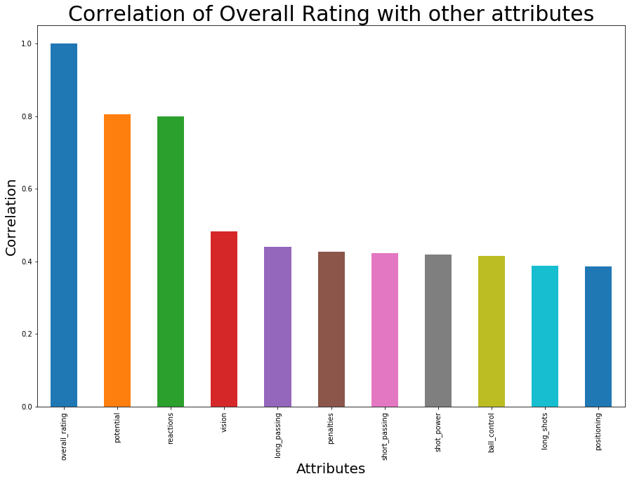

```python
#Plot a bar chart to show the correlation of overall rating and other attributes
plt.figure(figsize=(15,10))
top10.plot(kind='bar')
plt.xlabel("Attributes", size=20)
plt.ylabel('Correlation',size=20)
plt.title('Correlation of Overall Rating with other attributes', size=30)
plt.show()
```

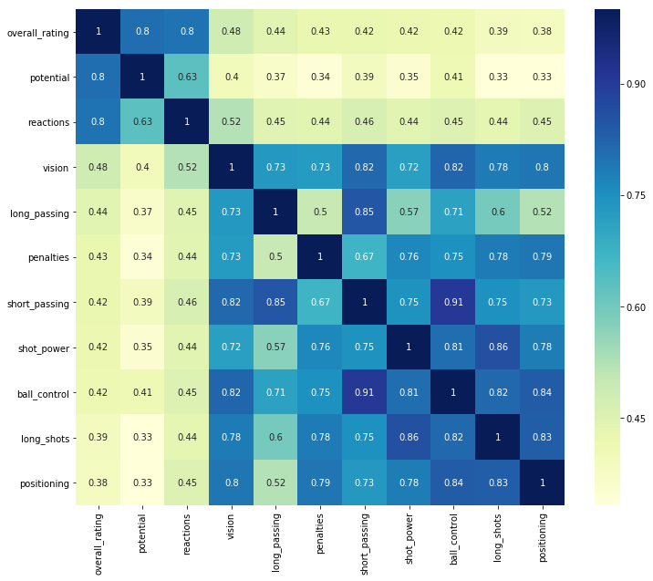

```python
#Let's use seaborn heatmap to visualize the corrlation
plt.figure(figsize=(12,10))
sns.heatmap(top10_df,cmap="YlGnBu", annot=True, annot_kws={"size": 10})
```

## Conclusions

### 1. Is match getting more boring now(in terms of the goals per match)?

#### No,during season 08/09 to season 15/16. there is a trend of the goals per match increasing but it is not significant. The difference of between Max and Min less than 7%.

### 2. Is there any home team adventage?

#### Yes, we found that overall home team win rate is about 46% while away team only 29%. We also look at the goals by different countries. It is obvious that home team has more goals than away team in all countries.

### 3. Which factors contribute to the overall-rating of a player?

#### By using Bar plot and Heatmap, it shows that the top 10 factors are 'potential', 'reactions', 'vision', 'long_passing','penalties', 'short_passing', 'shot_power', 'ball_control','long_shots', 'positioning'.

### Limitations

#### 1. There are very small portion missing data in the dataframe. We have to ignore these set of data.

#### 2. For study the goal trend, we only have 8 years data, which is not long enough to get a signaificant trend.

#### 3. For study the overall-rating of a player, we droped the attacking_work_rate and defensive_work_rate columns, since they are not quantitative data.